# Reproducing Vitting-Seerup et al 2018

Kristoffer Vitting-Seerup & Albin Sandelin

29th November 2018

### Purpose

This R markdown document reproduces the results presented in Vitting-Seerup *et al* 2018 manuscript entitled “IsoformSwitchAnalyzeR: Analysis of changes in genome-wide patterns of alternative splicing and its functional consequences”.

### Setup R Enviroment

By copy/paste the following R code into your R terminal you can be make sure the right version of IsoformSwitchAnalyzeR is installed:

```r
### If nessesary install IsoformSwitchAnalyzeR
if (!requireNamespace("IsoformSwitchAnalyzeR", quietly = TRUE)) {
    if (!requireNamespace("BiocManager", quietly = TRUE)) {
        install.packages("BiocManager")
    }
    BiocManager::install("IsoformSwitchAnalyzeR", version = "3.8")
}

### Check IsoformSwitchAnalyzeR version
if( packageVersion('IsoformSwitchAnalyzeR') < '1.1.10' ) {
    if (!requireNamespace("BiocManager", quietly = TRUE)) {
        install.packages("BiocManager")
    }
    BiocManager::install("IsoformSwitchAnalyzeR", version = "3.8")

    library(IsoformSwitchAnalyzeR)
}

### Load library
library(IsoformSwitchAnalyzeR)
```

### Load Data

First you will need to download the switchAnalyzeRlist made available in the Vitting-Seerup *et al* 2017 manuscript. The file can be downloaded via this [figshare link](https://ndownloader.figshare.com/files/8283803). This file contains the full annotated switchAnalyzeRlists resulting from our 2017 analysis of isoform switches in 12 TCGA cancer types (in all cases tumor vs normal adjecent). The resulting file ‘File_S1_switchAnalyzeRlists.Rdata’ can be loaded into R as follows:

```r
load('File_S1_switchAnalyzeRlists.Rdata')
```

This loads two R objects into the R environment. Here we will only use the “tcgaSwitchAnalyzeRlistSignificant” object - which only contain genes with statistically signficant isoform switches.

### Update switchAnalyzeRList to New Standards

The switchAnalyzeRList distributed with our 2017 manuscript were created with IsoformSwitchAnalyzeR v0.98.0. Since then we have added in reference ids to make it easier to work with multiple conditions in IsoformSwitchAnalyzeR. Therefore we need to update the old switchAnalyzeRlists with such feature:

```r
### Add refrence columns
tcgaSwitchAnalyzeRlistSignificant$isoformFeatures$iso_ref <- paste0(
    tcgaSwitchAnalyzeRlistSignificant$isoformFeatures$isoform_id,
    tcgaSwitchAnalyzeRlistSignificant$isoformFeatures$condition_1,
    tcgaSwitchAnalyzeRlistSignificant$isoformFeatures$condition_2
)
tcgaSwitchAnalyzeRlistSignificant$isoformFeatures$gene_ref <- paste0(
    tcgaSwitchAnalyzeRlistSignificant$isoformFeatures$gene_id,
    tcgaSwitchAnalyzeRlistSignificant$isoformFeatures$condition_1,
    tcgaSwitchAnalyzeRlistSignificant$isoformFeatures$condition_2
)
```

### Selecting Data of Interest

Here we only want to analyze the COAD and LIHC cancer types, so we subset for those:

```r
tcgaSubset <- subsetSwitchAnalyzeRlist(
    tcgaSwitchAnalyzeRlistSignificant,
    tcgaSwitchAnalyzeRlistSignificant$isoformFeatures$condition_1 %in% c('COAD_ctrl','LIHC_ctrl')
)
```

We are only interested in genes containing a significant isoform in either of these two cancer types. Therefore we subset to those genes which also gives a much faster run time for the rest of the analysis.

```r
tcgaSubset <- preFilter(
    tcgaSubset,
    reduceToSwitchingGenes  = TRUE,
    geneExpressionCutoff    = NULL,   # NULL disables filter to not change anything else
    isoformExpressionCutoff = NULL,   # NULL disables filter to not change anything else
    IFcutoff                = NULL    # NULL disables filter to not change anything else
)
```

```
## The fitering removed 10172 ( 86.32% of ) transcripts. There is now 1612 isoforms left
```

This leaves us with this switchAnalyzeRlist

```r
summary(tcgaSubset)
```

```
## This switchAnalyzeRlist list contains:
##  1612 isoforms from 781 genes
##  2 comparison from 4 conditions
##
## Switching features:
##                 Comparison switchingIsoforms switchingGenes
## 1 COAD_ctrl vs COAD_cancer               939            533
## 2 LIHC_ctrl vs LIHC_cancer               521            300
## 3                 combined              1376            781
##
## Feature analyzed:
## [1] "Isoform Swich Identification, ORFs, Signal Peptides, Protein Domains, Switch Consequences, Intron Retentions, Coding Potential"
```

### Define Features of Interest

In this manuscript we are not interested in all consequences and splice types that IsoformSwitchAnalyzeR can analyze - therefore we define these subsets of interest:

```r
consequenceOfInterest <- c(
    'intron_retention',
    'coding_potential',
    'domains_identified',
    'signal_peptide_identified'
)

splicingOfInterest <- c(
    'A3',
    'A5',
    'ES',
    'IR',
    'ATTS',
    'ATSS',
    'MES',
    'ES'
)
```

### Reanalyze with Extended IsoformSwitchAnalyzeR

The switchAnalyzeRList needs to be re-analyzed from the step of the alternative splicing (see overview in Supplementary figure S1A).

```r
### Analyze splicing (takes ~2 min)
tcgaSubset <- analyzeAlternativeSplicing(
    tcgaSubset,
    showProgress = FALSE
)

### Re-analyze switch consequences of interest (takes ~20 sec)
tcgaSubset <- analyzeSwitchConsequences(
    tcgaSubset,
    consequencesToAnalyze = consequenceOfInterest,
    showProgress = FALSE
)
```

To make the analysis of switch consequences and alternative splicing more comparable we only want to analyze switches with predicted consequences:

```r
### Subset to those with consequences
tcgaSubset <- subsetSwitchAnalyzeRlist(
    tcgaSubset,
    tcgaSubset$isoformFeatures$switchConsequencesGene
)

### Extract switch summary
extractSwitchSummary( tcgaSubset )
```

```
##                 Comparison nrIsoforms nrGenes
## 1 COAD_ctrl vs COAD_cancer        421     237
## 2 LIHC_ctrl vs LIHC_cancer        165     100
## 3                 combined        566     324
```

### Reproducing Main Figures

With the reanalyzed switchAnalyzeRlist we can now recreate the figures presented in Vitting-Seerup *et al* 2018. To generate vector graphic figures for the paper we simply used the following setup for each of the 6 sub-figures described in the rest of this document.

```
pdf(path/to/output/figureName.pdf)

# Add analysis/plotting function described below here

dev.off()
```

If, due to the small figure size, figure text needed to be made smaller modified we simply added the following argument to the function calls in the next section:

```
localTheme = theme_bw(base_size = 10)
```

**Figure 1A : Switch Consequence Enrichment**

```r
extractConsequenceEnrichment(
    tcgaSubset,
    analysisOppositeConsequence = TRUE,
    consequencesToAnalyze = consequenceOfInterest
)
```

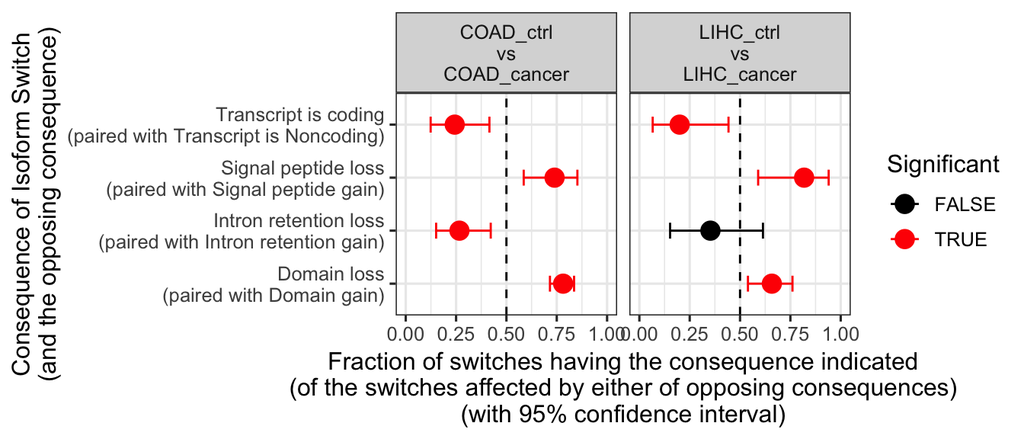

**Figure 1B : Splice Type Enrichment**

```r
extractSplicingEnrichment(
    tcgaSubset,
    splicingToAnalyze = splicingOfInterest
)
```

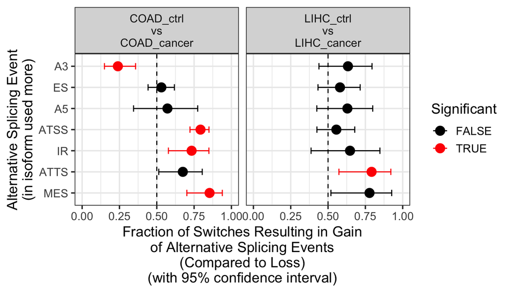

### Reproducing Supplementary Figures

**Figure S1A : Splicing Summary**

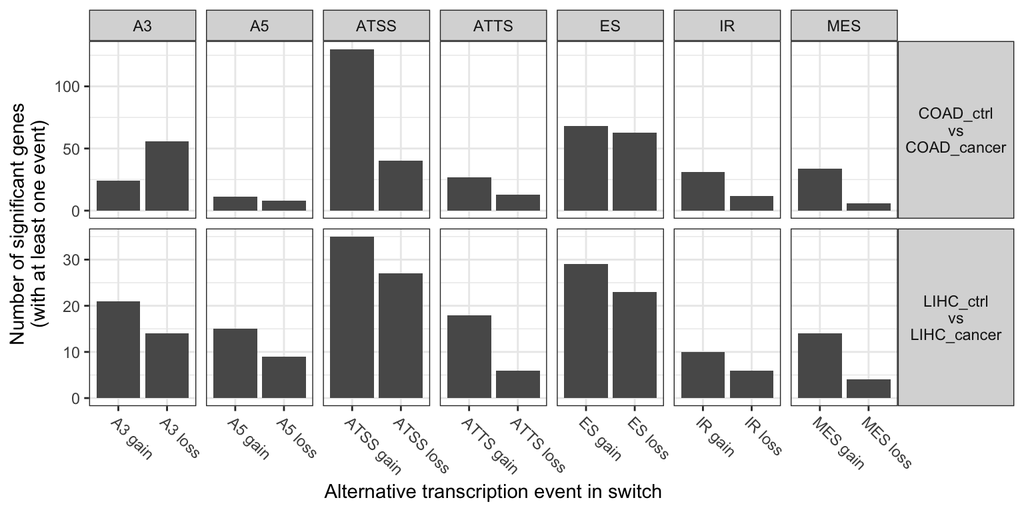

```r
extractSplicingSummary(
    tcgaSubset,
    splicingToAnalyze = splicingOfInterest,
    plotGenes = TRUE
)
```

**Figure S1B : Switch Consequence Summary**

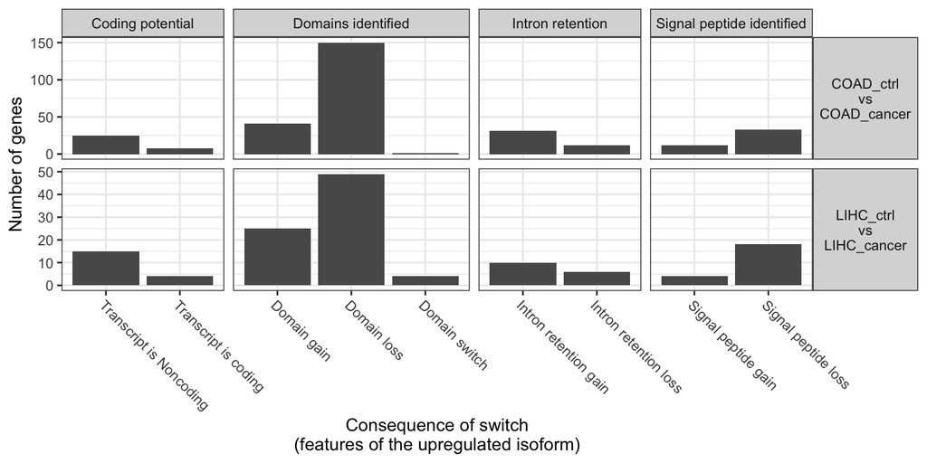

```r
extractConsequenceSummary(
    tcgaSubset,
    consequencesToAnalyze = consequenceOfInterest,
    plotGenes = TRUE
)
```

**Figure S1C : Consequence Enrichment Comparison**

```r
extractConsequenceEnrichmentComparison(
    switchAnalyzeRlist = tcgaSubset,
    consequencesToAnalyze = consequenceOfInterest,
    returnResult = FALSE
)
```

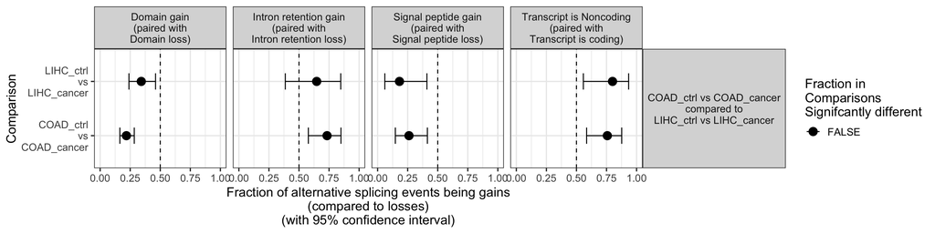

**Figure S1D : Splicing Enrichment Comparison**

```r
extractSplicingEnrichmentComparison(
    tcgaSubset,
    splicingToAnalyze = splicingOfInterest,
    returnResult = FALSE
)
```

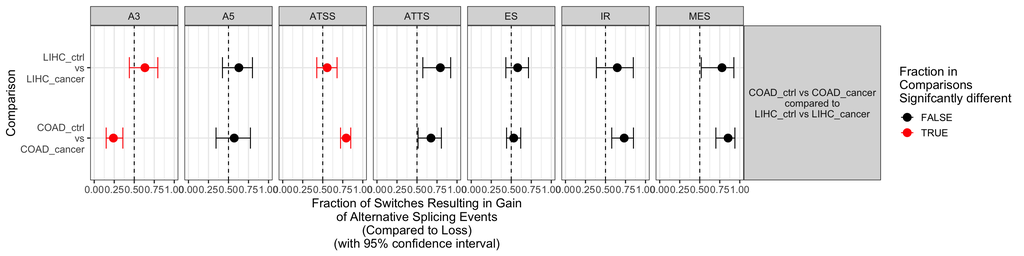